# Starting R and MOSAIC

Data Computing Instructors’ Workshop

## A note about these slides

The support for documentation creation in RStudio is great.

- These slides are HTML, but I created them in RMarkdown (+ a little bit of HTML fiddling)
- A single RMarkdown file can generate PDF, HTML, or Word
- No need to know HTML, LateX or Word
- But if you do, you can take advantage
- You will learn about RMarkdown later today

## Getting Oriented to RStudio

## Menu

- Files, Edit, Code, View, etc.
- Tools > Options for customization

## Panes and Tabs

- 4 **panes** (but some may be minimized)
- Each pane can have multiple **tabs**
- Options let you decide which tabs go in which panes

## Source Pane

- Where you will edit documents.
- Each document will be in its own tab.

Once you get used to editing, you'll want to invoke most of your commands directly from the keyboard.

## Keyboard Shortcuts

### R is case sensitive

- many students are *not* case sensitive

### Arrows and Tab

- up/down arrows scroll through history
- TAB completion can simplify typing

### If all else fails, try ESC

- If you see a + prompt, it means R is waiting for more input
- If this is unintentional, you probably have a typo
- ESC will get you pack to the command prompt

## Caclulation and Assignment

- Basic calculation is similar to a calculator
- Results can be stored in named variables with `<-` (or `->`)
- Good place to get started with R (but we will learn other options shortly)

```r
product <- 5 * 3 * 27
product
```

```
## [1] 405
```

```r
sqrt(100)
```

```
## [1] 10
```

```r
log10(product)
```

```
## [1] 2.607455
```

## Environment Tab

- Shows the objects in the working environment
- Broom icon clears the working environment

[figure not shown]

## Packages Tab

- List all installed packages
- Install new packages from CRAN
- Load/unload packages by clicking check boxes
- Click on name of package to find vignettes and other info

## Help!

RStudio provides several ways to get help

- Help tab documents functions and data sets in packages
- `?` followed by name of function or data set
- Package vignettes
- TAB completion provides useful hints

## Start reading R

It's more important to be able to read than to write.

If you can read, you can copy and modify. Almost all computer programming is "copy and customize."

### Example

```r
After1950 <-
  BabyNames %>%
  filter(year > 1950) %>%
  group_by(name) %>%
  tally()
```

## Parts of Speech

From the dictionarty > part of speech *noun*

> plural noun: parts of speech a category to which a word is assigned in accordance with its syntactic functions. In English the main parts of speech are noun, pronoun, adjective, determiner, verb, adverb, preposition, conjunction, and interjection.

## Parts of Speech in R

Almost everything you will see in R will be one of these:

- function
- argument,
- data table
- variable
- formula
- assignment
- constant

## In more detail …

- functions
  - transform inputs into output
  - reading hint: function name always followed by `(` and `)`
- arguments
  - specify the details of what the function is to do: inputs and parameters
  - reading hint: always inside `(` and `)`, separated by commas
  - named arguments: e.g. `data = Galton`
- data tables
  - store data, like a spreadsheet
  - reading hint: found after `data =`
  - reading hint: Convention, start with an Upper case letter.
- variables
  - the columns of data tables. Generally have a name.
  - reading hint: *always* used in arguments to functions, never outside
- formulas
  - specify relationships among variables in data and in mathematics
  - reading hint: there will *always* be a `~` tilde
- assignment
  - store a result under a name
  - reading hint: object name followed by `<-`
  - we'll also see *pipes* to connect commands without storing intermediate results, `%>%`
- constants
  - specify a value that's unchanging
  - numbers: e.g. `7` or `7.3` or `7.3e6`
  - character strings: `red`, `"my_data_file.csv"`, `"Hello, Susan."`
  - language keywords, e.g. logicals, etc.: `TRUE`, `FALSE`, `NULL`, `NA`

## Your Turn

1. Identify the R part of speech of each component in the following expressions:

```r
hmod <- lm( height ~ father, data = subset(Galton, sex == "M"))
```

```r
hfun <- makeFun(hmod)
```

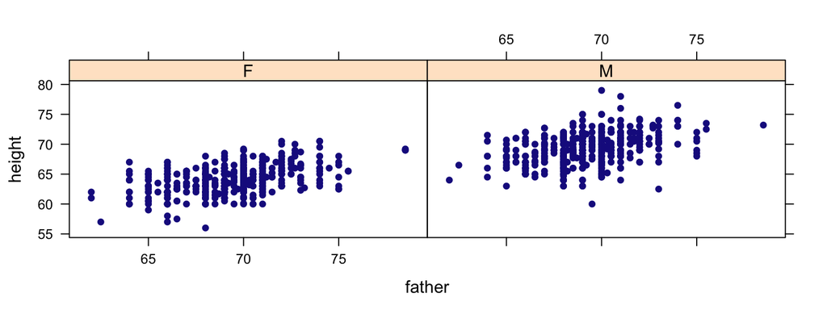

```r
xyplot(height ~ father | sex, data = Galton)
```

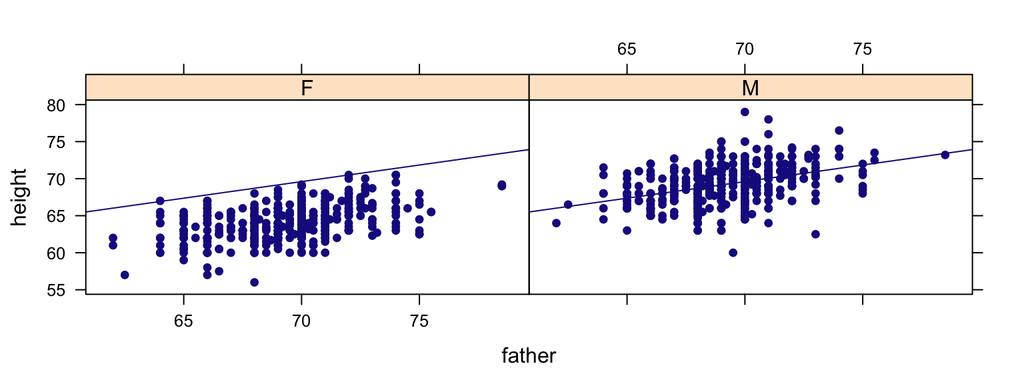

```r
plotFun( hfun(x) ~ x, add = TRUE)
```

1. Consider this command chain:

```r
Princes <-
  BabyNames %>%
  filter(grepl("Prince",name)) %>%
  group_by(year) %>%
  summarise(total = sum(count))
```

Explain your reasoning.

## Micro-languages

A subset of R with a clear, consistent syntax suited to a particular task.

- Speeds up learning.
- Allows the user to generalize old patterns to new tasks.

We'll use three:

1. `mosaic` — for intro stats (and calculus)
2. `dplyr` — for data wrangling
3. `ggplot2` — for high-quality, flexible graphics

Each integrates well with R as a whole, so you can fall back on regular syntax for tasks that aren't served by the micro-language.

## Start your session …

Start your R session (or RMD document) by loading the packages that implement the micro-languages:

```r
require(mosaic)
```

MOSAIC will automatically load `dplyr` and `ggplot2` for you.

## Crib Sheets

The micro-languages' quick references can be very short, yet comprehensive.

## The Most Important MOSAIC Template

## **goal ( yyy ~ xxx , data = mydata )**

## The Most Important MOSAIC Template

## **goal ( y ~ x , data = mydata )**

## The Most Important MOSIAC Template

## **goal ( y ~ x , data = mydata , …)**

### Other versions:

```r
# simpler version
goal( ~ x, data = mydata )
# fancier version
goal( y ~ x | z , data = mydata )
# unified version
goal( formula , data = mydata )
```

## 2 Questions

## **goal ( y ~ x , data = mydata )**

### What do you want R to do? (goal)

### What must R know to do that?

## 2 Questions

## **goal ( y ~ x , data = mydata )**

### What do you want R to do? (goal)

- This determines the function to use

### What must R know to do that?

- This determines the inputs to the function
- Must identify the variables and data frame

### What is the Goal?

- a scatter plot

### What does R need to know?

- which variable goes where
- which data set

### What is the Goal?

- a scatter plot (`xyplot()`)

### What does R need to know?

- which variable goes where (`births ~ dayofyear`)
- which data set (`data=Births78`)
  - use `?Births78` for documentation

## How do we make this plot?

## **goal ( y ~ x , data = mydata )**

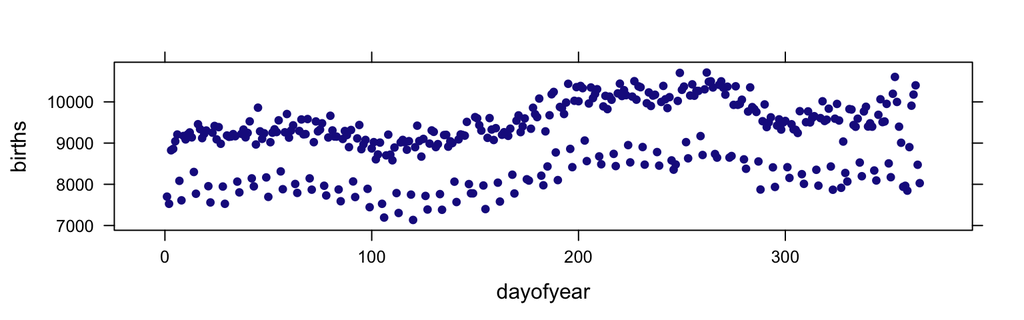

```r
xyplot( births ~ dayofyear, data=Births78)
```

## Your turn: How do you make this plot?

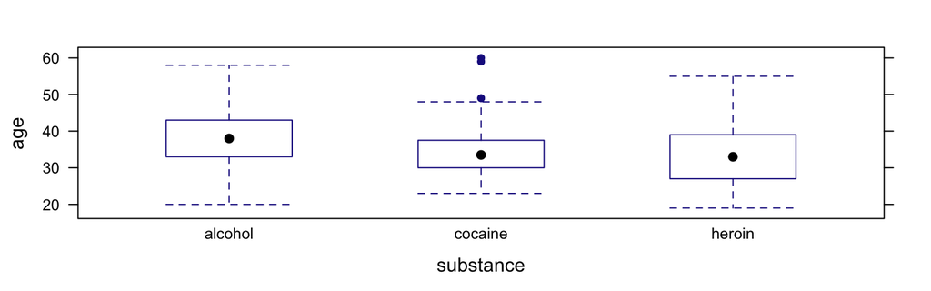

### Two Questions?

## Your turn: How do you make this plot?

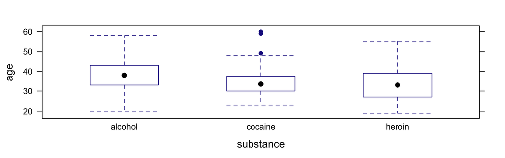

1. Command: `bwplot()`
2. The data: `HELPrct`
- Variables: `age`, `substance`
- use `?HELPrct` for info about data

## Your turn: How do you make this plot?

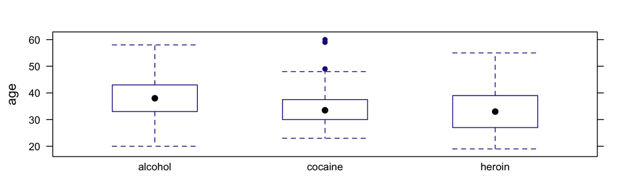

```r
bwplot( age ~ substance, data=HELPrct)
```

## Your turn: How about this one?

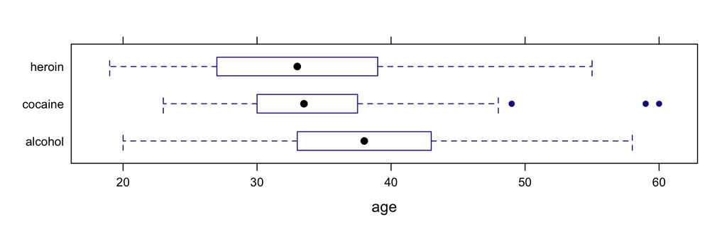

1. Command: `bwplot()`
2. The data: `HELPrct`
- Variables: `age`, `substance`
- use `?HELPrct` for info about data

## Your turn: How about this one?

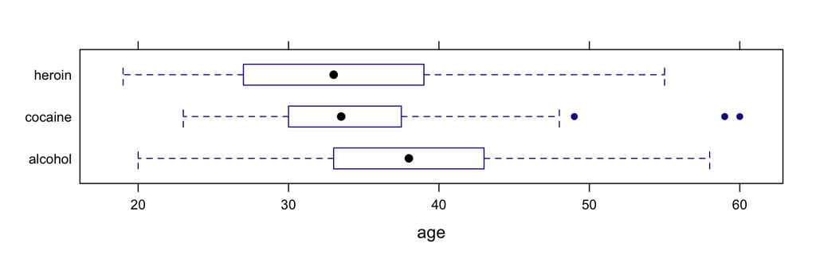

```r
bwplot( substance ~ age, data=HELPrct )
```

## Graphical Summaries: One Variable

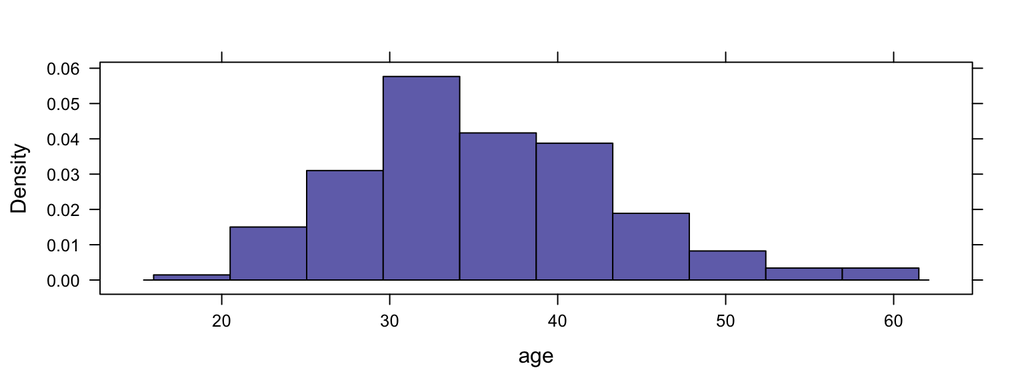

```r
histogram( ~ age, data=HELPrct)
```

Note: When there is **one variable** it is on the **right side** of the formula.

## Graphical Summaries: Overview

### One Variable

```r
  histogram( ~age, data=HELPrct )
densityplot( ~age, data=HELPrct )
     bwplot( ~age, data=HELPrct )
     qqmath( ~age, data=HELPrct )
freqpolygon( ~age, data=HELPrct )
   bargraph( ~sex, data=HELPrct )
```

### Two Variables

```r
xyplot(  i1 ~ age,       data=HELPrct )
bwplot( age ~ substance, data=HELPrct )
bwplot( substance ~ age, data=HELPrct )
```

- **i1** average number of drinks (standard units) consumed per day in the past 30 days (measured at baseline)

## The Graphics Template

### One variable

### **plotname ( ~ x , data = mydata , …)**

- `histogram()`, `qqmath()`, `densityplot()`, `freqpolygon()`, `bargraph()`

### Two Variables

### **plotname ( y ~ x , data = mydata , …)**

- `xyplot()`, `bwplot()`

## Your turn

Create a plot of your own choosing with one of these data sets

```r
names(KidsFeet)    # 4th graders' feet
?KidsFeet
```

```r
names(Utilities)   # utility bill data
?Utilities
```

```r
names(NHANES)      # body shape, etc.
?NHANES
```

## groups and panels

- Add `groups =` group to overlay.
- Use `y ~ x | z` to create multipanel plots.

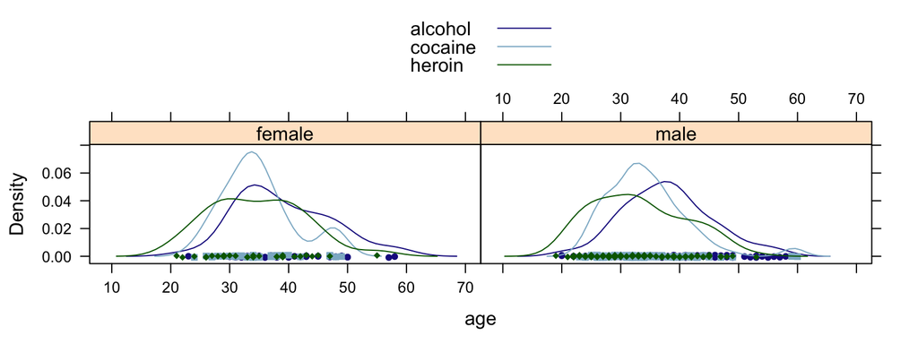

```r
densityplot( ~ age | sex, data=HELPrct,
               groups=substance,  auto.key=TRUE)
```

## Bells & Whistles

- titles
- axis labels
- colors
- sizes
- transparency
- etc, etc.

My approach:

- Let the students ask or
- Let the data analysis drive

## Bells and Whistles

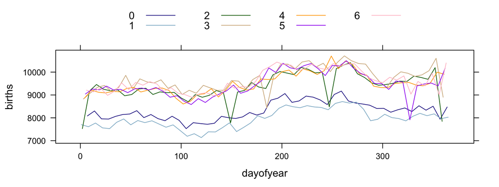

```r
xyplot( births ~ dayofyear, data=Births78,
  groups=dayofyear %% 7, type='l',
  auto.key=list(columns=4, lines=T, points=F),
  par.settings=list(
    superpose.line=list( lty=1 ) ))
```

## Numerical Summaries: One Variable

Big idea: Replace plot name with summary name

- Nothing else changes

```
## [1] 35.7
```

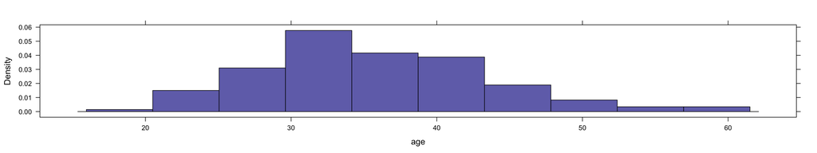

```r
histogram( ~ age, data=HELPrct )
     mean( ~ age, data=HELPrct )
```

## Other Summaries

The mosaic package includes formula aware versions of `mean()`, `sd()`, `var()`, `min()`, `max()`, `sum()`, `IQR()`, …

Also provides `favstats()` to compute our favorites.

```r
favstats( ~ age, data=HELPrct )
```

```
##  min Q1 median Q3 max mean   sd   n missing
##   19 30     35 40  60 35.7 7.71 453       0
```

## Tallying

```r
tally( ~ sex, data=HELPrct)
```

```
##
## female   male
##    107    346
```

```r
tally( ~ substance, data=HELPrct)
```

```
##
## alcohol cocaine  heroin
##     177     152     124
```

## Numerical Summaries: Two Variables

Three ways to think about this. All do the same thing.

```r
sd(   age ~ substance, data=HELPrct )
sd( ~ age | substance, data=HELPrct )
sd( ~ age, groups=substance, data=HELPrct )
```

```
## alcohol cocaine  heroin
##    7.65    6.69    7.99
```

## Numerical Summaries: Tables

```r
tally( sex ~ substance, data=HELPrct )
```

```
##         substance
## sex      alcohol cocaine heroin
##   female      36      41     30
##   male       141     111     94
```

```r
tally( ~ sex + substance, data=HELPrct )
```

```
##         substance
## sex      alcohol cocaine heroin
##   female      36      41     30
##   male       141     111     94
```

## Numerical Summaries

```r
mean( age ~ substance | sex, data=HELPrct )
```

```
##  A.F  C.F  H.F  A.M  C.M  H.M    F    M
## 39.2 34.9 34.7 38.0 34.4 33.1 36.3 35.5
```

```r
mean( age ~ substance | sex, data=HELPrct, .format="table" )
```

```
##   substance sex mean
## 1         A   F 39.2
## 2         A   M   38
## 3         C   F 34.9
## 4         C   M 34.4
## 5         H   F 34.7
## 6         H   M 33.1
```

- I've abbreviated the names to make things fit on slide
- Also works for `median()`, `min()`, `max()`, `sd()`, `var()`, `favstats()`, etc.

## One Template to Rule a Lot

- single and multiple variable graphical summaries
- single and multiple variabble numerical summaries
- linear models

```r
  mean( age ~ sex, data=HELPrct )
bwplot( age ~ sex, data=HELPrct )
    lm( age ~ sex, data=HELPrct )
```

[output not shown]

```
## female   male
##   36.3   35.5
```

```
## (Intercept)     sexmale
##      36.252      -0.784
```

## Exercises

Answer each question with both a numerical summary and a graphical summary.

1. Are boys feet larger than girls feet? (`KidsFeet`)
2. Do boys and girls have differently shaped feet? (`KidsFeet`)

## Some Other Things in mosaic

## Some other things

The `mosaic` package includes some other things, too

- Data sets (you've already seen some of them)
- xtras: `xchisq.test()`, `xpnorm()`, `xqqmath()`
- `mplot()`
- `mplot(HELPrct)` interactive plot creation
- replacements for `plot()` in some situations
- simplified `histogram()` controls (e.g., `width`)
- simplified ways to add onto lattice plots

## xpnorm()

```r
xpnorm( 700, mean=500, sd=100)
```

```
##
## If X ~ N(500,100), then
##
##  P(X <= 700) = P(Z <= 2) = 0.9772
##  P(X >  700) = P(Z >  2) = 0.0228
```

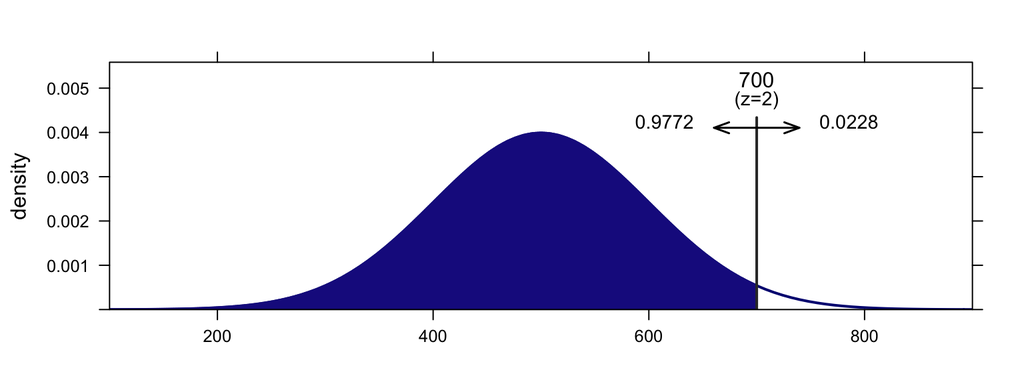

```
## [1] 0.977
```

## xpnorm()

```r
xpnorm( c(300, 700), mean=500, sd=100)
```

```
##
## If X ~ N(500,100), then
##
##  P(X <= 300) = P(Z <= -2) = 0.0228
##      P(X <= 700) = P(Z <= 2) = 0.9772
##  P(X >  300) = P(Z >  -2) = 0.9772
##      P(X >  700) = P(Z >  2) = 0.0228
```

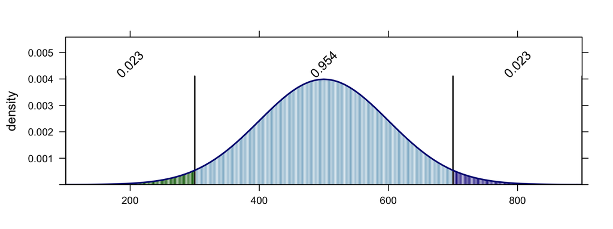

```
## [1] 0.0228 0.9772
```

## xchisq.test()

```r
xchisq.test(phs)
```

[output not shown]